# Surrey/Hants Primary School Admissions and Performance

Exploratory Data Analysis

Clare Gibson

2021-06-22

# 1 Introduction

This document forms part of a project I am working on to analyse and present primary school admissions and performance data in Surrey and Hampshire in a meaningful way to parents looking to choose a school for their child. The full projects, including all source data and scripts, can be found on [Github](https://github.com/clarelgibson/schools).

This project contains data and analysis relating to primary school admissions and performance data in Surrey and Hampshire for academic years beginning September 2016. Full details of the data sources used for this analysis can be found in the [README](https://github.com/clarelgibson/schools#readme) file within the Github repo.

The purpose of this exploratory data analysis (EDA) is to get to know the data, determine what level of cleaning or wrangling may be required and uncover potential insights to explore further.

We will make use of several libraries during this EDA:

```r
library(tidyverse)
library(janitor)
```

# 2 Setup

First we need to run the `read.R` script to read in the source data for this project. Source data files can be found in the `data-in` directory of this repo.

```r
source("read.R")
```

You will notice that each of these data frames has the prefix `r_` at the start of the variable name. This denotes the variable as being the ‘raw’ version of the data (i.e. exactly as it appeared at source). When we start to clean and wrangle this data, we will store the manipulated version as a new variable, without the `r_` prefix. In this way, we always have a copy of the raw data to refer back to if needed.

# 3 School offers

## 3.1 Cleaning

We will start this EDA by examining the `r_offers_la` data. Let’s view a summary of this data frame.

```r
glimpse(r_offers_la)
```

```
## Rows: 2,588
## Columns: 36
## $ time_period                                <dbl> 202122, 202122, 202122, 202…
## $ time_identifier                            <chr> "Academic year", "Academic …
## $ geographic_level                           <chr> "National", "Regional", "Re…
## $ country_code                               <chr> "E92000001", "E92000001", "…
## $ country_name                               <chr> "England", "England", "Engl…
## $ region_code                                <chr> NA, "E12000001", "E12000002…
## $ region_name                                <chr> NA, "North East", "North We…
## $ new_la_code                                <chr> NA, NA, NA, NA, NA, NA, NA,…
## $ old_la_code                                <dbl> NA, NA, NA, NA, NA, NA, NA,…
## $ la_name                                    <chr> NA, NA, NA, NA, NA, NA, NA,…
## $ school_phase                               <chr> "Primary", "Primary", "Prim…
## $ NC_year_admission                          <chr> ":", ":", ":", ":", ":", ":…
## $ admission_numbers                          <dbl> 709911, 33627, 96499, 71799…
```

[output cut: 23 more lines]

The first thing I like to do after reading in data in its raw form is to clean the column headings so that they are in a friendly format for R. That means avoiding spaces and special characters and converting everything to lower case. In this case, the headings in the raw data are pretty clean already, but I can see one or two that have some capitalization. R has a handy package called `janitor` which includes a `clean_names()` function. We can use this function as the first step in cleaning this data. Since I am now manipulating the raw data, I will save these changes into a new variable called `offers_la` (removing the `r_` prefix).

```r
offers_la <- r_offers_la %>%
  clean_names()
```

Looking again at the summary of the data, we can see that there is a column called `geographic_level`, which seems to indicate that the records may be at differing levels of granularity. In fact, we can see this is the case by looking at the unique values of `geographic_level`.

```r
table(offers_la$geographic_level)
```

```
##
## Local authority        National        Regional
##            2412              16             160
```

The records denoted as either ‘National’ or ‘Regional’ in this column are simply rolled-up subtotals of the ‘Local authority’ records. This is essentially capturing the same data twice, and could cause us issues if we want to perform calculations across the entire data frame. Given that we can easily calculate subtotals ourselves if needed, we will remove these records for our clean data frame.

```r
offers_la <- offers_la %>%
  filter(geographic_level == "Local authority")
```

Once I have clean column headings and the data is filtered, the next thing I like to do is to view the unique values of each character-type column. This helps me get a feel for the categories that our data is divided into. It can also help reveal if there is any data cleaning required. I’ll save the unique values into a new df with the prefix `u_` (for ‘unique’).

```r
u_offers_la <- offers_la %>%
  select(where(is.character)) %>%
  lapply(unique)

u_offers_la
```

```
## $time_identifier
## [1] "Academic year"
##
## $geographic_level
## [1] "Local authority"
##
## $country_code
## [1] "E92000001"
##
## $country_name
## [1] "England"
##
## $region_code
##  [1] "E13000001" "E13000002" "E12000005" "E12000002" "E12000003" "E12000001"
##  [7] "E12000009" "E12000006" "E12000008" "E12000004"
```

[output cut: 122 more lines]

I notice a few items that I would like to clean up. First, I would like to mutate the `time_period` column (a numeric column in `offers_la`) so that it displays only the start year of the academic year (i.e. ‘202021’ becomes ‘2020’. We can also rename it to `year_of_entry` for clarity).

```r
offers_la <- offers_la %>%
  mutate(time_period = as.character(time_period),
         time_period = str_sub(time_period, 1, 4),
         time_period = as.numeric(time_period)) %>%
  rename(year_of_entry = time_period)

head(offers_la$year_of_entry)
```

```
## [1] 2021 2021 2021 2021 2021 2021
```

In the list of unique values `u_offers_la` I can see one column that appears to be of the wrong type. Look at `no_of_preferences`.

```r
u_offers_la$no_of_preferences
```

```
## [1] "6" "3" "5" "4"
```

This is a character column but the values are all numbers. I think this is because before we filtered the data to remove the regional and national totals, this column contained some character values denoting missing values. Now that we have filtered those records out, we can safely convert this column to numeric type.

```r
offers_la <- offers_la %>%
  mutate(no_of_preferences = as.numeric(no_of_preferences))

glimpse(offers_la$no_of_preferences)
```

```
##  num [1:2412] 6 6 6 6 6 6 6 6 6 6 ...
```

Another thing I noticed when I first reviewed the data with `glimpse` was that there are columns containing percentages where the values follow the format `97.6`, `88.3`, `3.2` etc.

```r
offers_la %>%
  select(ends_with("_percent")) %>%
  head()
```

```
## # A tibble: 6 x 10
##   online_apps_perc… first_preference_of… second_preference_… third_preference_o…
##               <dbl>                <dbl>               <dbl>               <dbl>
## 1             100                   89.3                3.57                0
## 2              99.9                 77.8                9.74                3.95
## 3              99.6                 88.9                6.64                1.93
## 4              98.1                 91.0                4.38                1.89
## 5              98.3                 79.6                8.78                3.67
## 6             100                   78.5                8.71                3.56
## # … with 6 more variables: one_of_the_three_preference_offers_percent <dbl>,
## #   preferred_school_offer_percent <dbl>, non_preferred_offer_percent <dbl>,
## #   no_offer_percent <dbl>, schools_in_la_offer_percent <dbl>,
## #   schools_in_another_la_offer_percent <dbl>
```

I would like to convert these to decimals (i.e. divide each value by 100) to make it easier to work with in Tableau later.

```r
offers_la <- offers_la %>%
  mutate(across(ends_with("_percent"), ~ .x / 100))

offers_la %>%
  select(ends_with("_percent")) %>%
  head()
```

```
## # A tibble: 6 x 10
##   online_apps_perc… first_preference_of… second_preference_… third_preference_o…
##               <dbl>                <dbl>               <dbl>               <dbl>
## 1             1                    0.893              0.0357              0
## 2             0.999                0.778              0.0974              0.0395
## 3             0.996                0.889              0.0664              0.0193
## 4             0.981                0.910              0.0438              0.0189
## 5             0.983                0.796              0.0878              0.0367
## 6             1                    0.785              0.0871              0.0356
## # … with 6 more variables: one_of_the_three_preference_offers_percent <dbl>,
## #   preferred_school_offer_percent <dbl>, non_preferred_offer_percent <dbl>,
## #   no_offer_percent <dbl>, schools_in_la_offer_percent <dbl>,
## #   schools_in_another_la_offer_percent <dbl>
```

## 3.2 Exploring

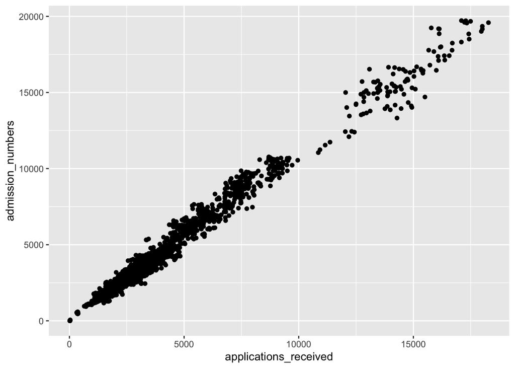

```r
ggplot(offers_la) +
  geom_point(mapping = aes(x = applications_received, y = admission_numbers))
```